# Data Analysis Workflow with Iris Dataset

R. Burke Squires

June 2025

# Introduction

This R Markdown document demonstrates a data analysis workflow using the `iris` dataset. We’ll explore the dataset, visualize the data, and create a simple classification model.

# Data Exploration

First, let’s take a look at the `iris` dataset.

```r
head(iris)
```

```
##   Sepal.Length Sepal.Width Petal.Length Petal.Width Species
## 1          5.1         3.5          1.4         0.2  setosa
## 2          4.9         3.0          1.4         0.2  setosa
## 3          4.7         3.2          1.3         0.2  setosa
## 4          4.6         3.1          1.5         0.2  setosa
## 5          5.0         3.6          1.4         0.2  setosa
## 6          5.4         3.9          1.7         0.4  setosa
```

```r
summary(iris)
```

```
##   Sepal.Length    Sepal.Width     Petal.Length    Petal.Width
##  Min.   :4.300   Min.   :2.000   Min.   :1.000   Min.   :0.100
##  1st Qu.:5.100   1st Qu.:2.800   1st Qu.:1.600   1st Qu.:0.300
##  Median :5.800   Median :3.000   Median :4.350   Median :1.300
##  Mean   :5.843   Mean   :3.057   Mean   :3.758   Mean   :1.199
##  3rd Qu.:6.400   3rd Qu.:3.300   3rd Qu.:5.100   3rd Qu.:1.800
##  Max.   :7.900   Max.   :4.400   Max.   :6.900   Max.   :2.500
##        Species
##  setosa    :50
##  versicolor:50
##  virginica :50
##
##
##
```

The `iris` dataset contains 150 observations of iris flowers, with four measurements (sepal length, sepal width, petal length, and petal width) and the species of the iris.

# Data Visualization

Now, let’s visualize the relationships between the variables using scatter plots.

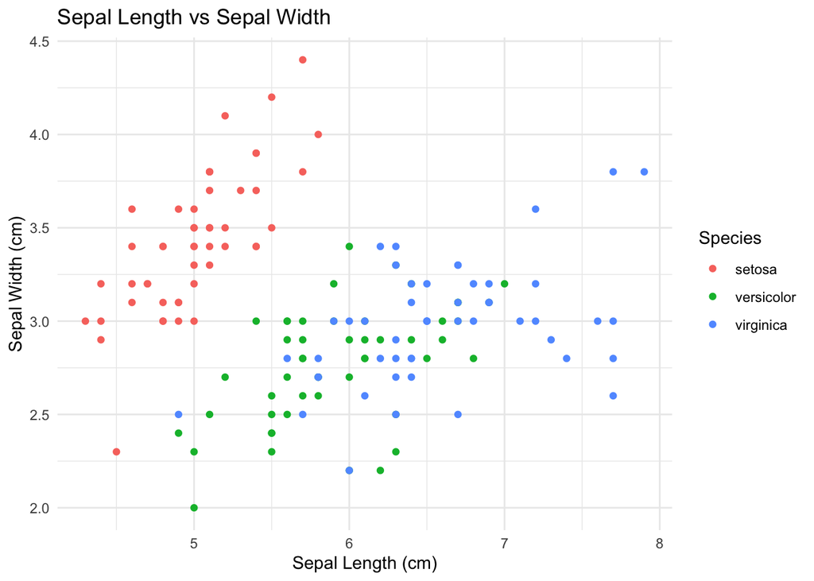

```r
ggplot(iris, aes(x = Sepal.Length, y = Sepal.Width, color = Species)) +
  geom_point() +
  theme_minimal() +
  labs(title = "Sepal Length vs Sepal Width",
       x = "Sepal Length (cm)",
       y = "Sepal Width (cm)")
```

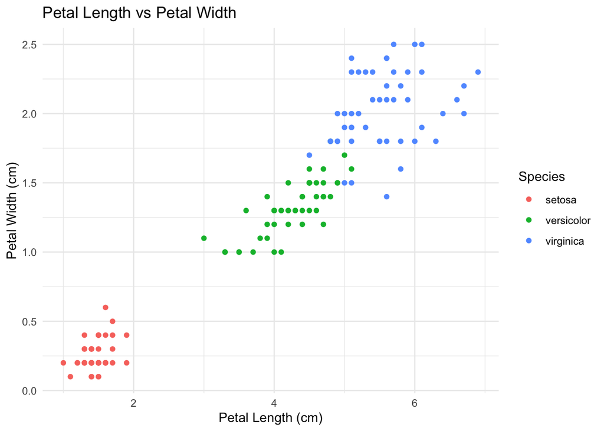

```r
ggplot(iris, aes(x = Petal.Length, y = Petal.Width, color = Species)) +
  geom_point() +
  theme_minimal() +
  labs(title = "Petal Length vs Petal Width",
       x = "Petal Length (cm)",
       y = "Petal Width (cm)")
```

The scatter plots suggest that the species are somewhat separable based on petal and sepal measurements.

# Model Creation

We’ll create a simple classification model using the k-Nearest Neighbors (k-NN) algorithm. First, we’ll split the dataset into training and testing sets.

```r
set.seed(42)
train_index <- createDataPartition(iris$Species, p = 0.8, list = FALSE)
train_data <- iris[train_index, ]
test_data <- iris[-train_index, ]
```

Now, let’s train the k-NN model.

```r
model <- train(Species ~ ., data = train_data, method = "knn", trControl = trainControl(method = "cv", number = 10))
model
```

```
## k-Nearest Neighbors
##
## 120 samples
##   4 predictor
##   3 classes: 'setosa', 'versicolor', 'virginica'
##
## No pre-processing
## Resampling: Cross-Validated (10 fold)
## Summary of sample sizes: 108, 108, 108, 108, 108, 108, ...
## Resampling results across tuning parameters:
##
##   k  Accuracy   Kappa
##   5  0.9750000  0.9625
##   7  0.9750000  0.9625
##   9  0.9666667  0.9500
##
## Accuracy was used to select the optimal model using the largest value.
## The final value used for the model was k = 7.
```

Finally, we’ll evaluate the model’s performance on the test dataset.

```r
predictions <- predict(model, test_data)
confusionMatrix(predictions, test_data$Species)
```

```
## Confusion Matrix and Statistics
##
##             Reference
## Prediction   setosa versicolor virginica
##   setosa         10          0         0
##   versicolor      0          9         1
##   virginica       0          1         9
##
## Overall Statistics
##
##                Accuracy : 0.9333
##                  95% CI : (0.7793, 0.9918)
##     No Information Rate : 0.3333
##     P-Value [Acc > NIR] : 8.747e-12
##
##                   Kappa : 0.9
##
##  Mcnemar's Test P-Value : NA
##
## Statistics by Class:
##
##                      Class: setosa Class: versicolor Class: virginica
## Sensitivity                 1.0000            0.9000           0.9000
## Specificity                 1.0000            0.9500           0.9500
## Pos Pred Value              1.0000            0.9000           0.9000
## Neg Pred Value              1.0000            0.9500           0.9500
## Prevalence                  0.3333            0.3333           0.3333
## Detection Rate              0.3333            0.3000           0.3000
## Detection Prevalence        0.3333            0.3333           0.3333
## Balanced Accuracy           1.0000            0.9250           0.9250
```

The k-NN model achieves a high accuracy on the test dataset, indicating that it’s able to classify the iris species reasonably well based on the four measurements provided.

# Conclusion

In this R Markdown document, we’ve demonstrated a data analysis workflow using the `iris` dataset. Through data exploration, visualization, and model creation, we’ve shown that the iris species can be classified using their petal and sepal measurements.